# Sampling

## Sampling Error

Sampling error is the gap between the sampling frame and the sample.

## Sampling Error

Surveys like the Assateague Horse Census don’t really have “sampling error” because they attempt to count the whole population

…but sampling is a practical necessity in most cases, and so sampling error is ubiquitous.

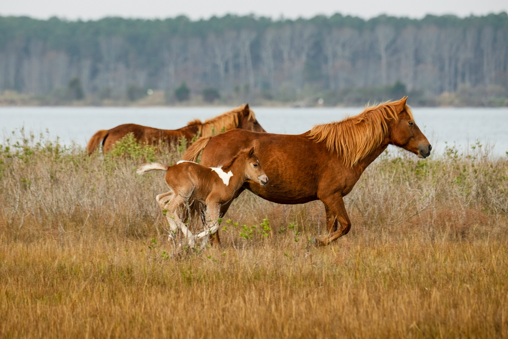

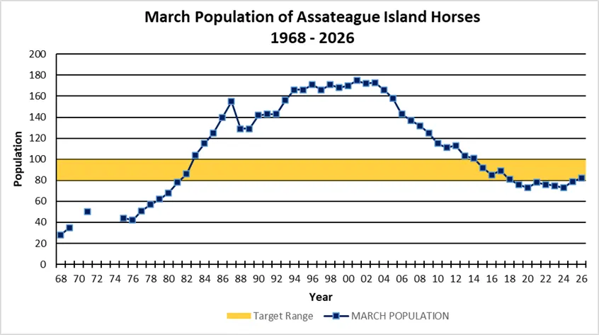

## Sampling Distributions

The Sampling Distribution is the distribution of sample statistics across all possible realizations of a sample.

## Sampling Distributions

We want to use samples to estimate population parameters. The sampling distribution helps us understand the range and probability of sampling errors that we might encounter.

[figure not shown]

### Sampling Distribution: example

Imagine we’ve got test scores for 8 students. We want to use a sample of size 2 to estimate the average score for all 8 students.

$$72, 74, 76, 77, 81, 84, 85, 91 \\
(\text{Average} = 80 )$$

The sampling distribution for a sample of size 2 from this “population” would just be every possible combination of 2 values: $[72, 74], [72, 76], [72, 77]...$

### Sampling Distribution: example

- There are 28 possible sample realizations.
- The “error” for each realization is just the difference between the true population mean (80) and the sample average.

| Sample | Mean | Error |
| --- | --- | --- |
| [72, 74] | 73.0 | -7.0 |
| [72, 76] | 74.0 | -6.0 |
| [72, 77] | 74.5 | -5.5 |
| [72, 81] | 76.5 | -3.5 |
| [72, 84] | 78.0 | -2.0 |
| [72, 85] | 78.5 | -1.5 |
| [72, 91] | 81.5 | 1.5 |
| [74, 76] | 75.0 | -5.0 |
| [74, 77] | 75.5 | -4.5 |
| [74, 81] | 77.5 | -2.5 |

Some sample realizations

## Sampling Distribution: example

I can use the full sampling distribution to answer questions about the probability of getting a particular sample mean.

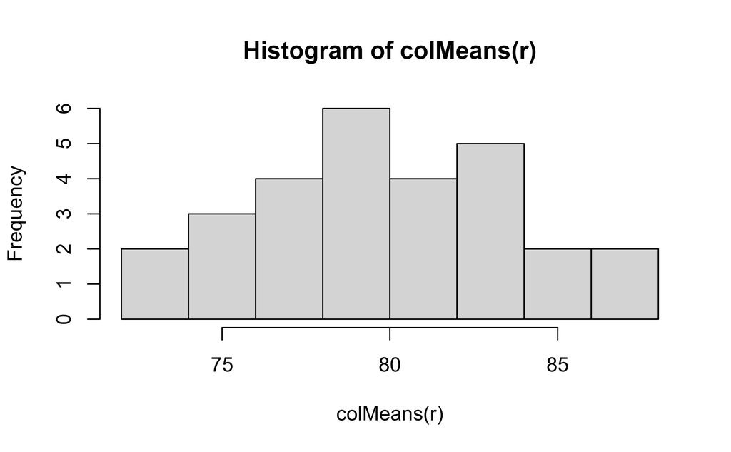

```r
data<-c(72, 74, 76, 77, 81, 84, 85, 91)
# get all combinations of size = 2
r<-combn(data, 2)
# histogram of all possible means:
hist(colMeans(r))
```

## Sampling Distribution: example

Or I can subtract the population mean from each average to get the distribution of sampling errors:

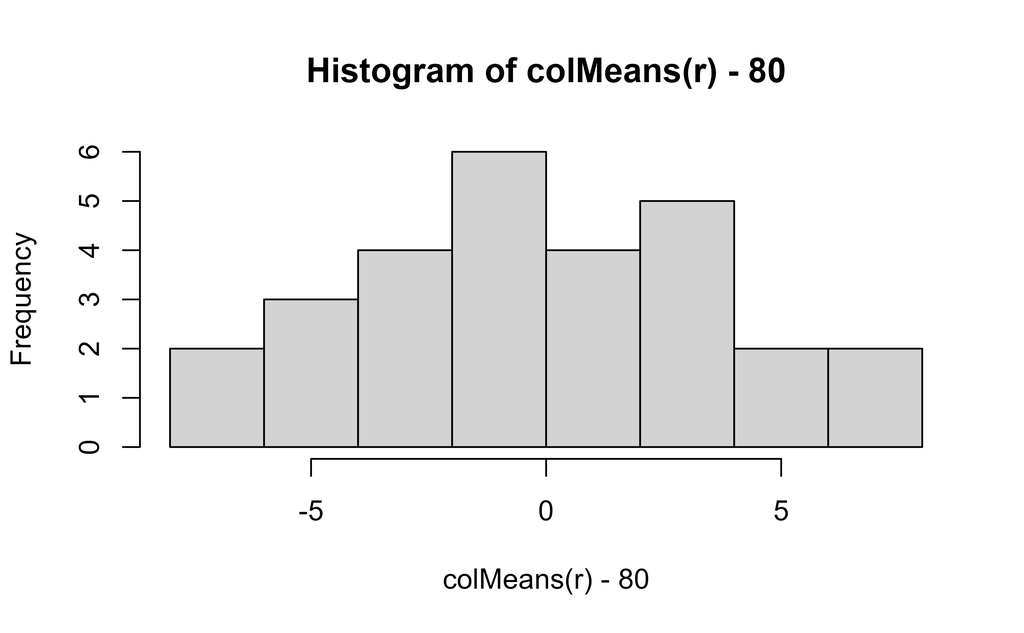

```r
data<-c(72, 74, 76, 77, 81, 84, 85, 91)
# get all combinations of size = 2
r<-combn(data, 2)
# histogram of all possible errors:
hist(colMeans(r)-80)
```

## Sampling Distribution

In practice, we just have a single sample realization, and we don’t know the true value of the population parameter.

However, we can use our sample to make some inferences about the properties of the sampling distribution (such as its mean and variance).

### Distributions

Keep in mind: this means we have three different distributions to worry about!

- The distribution of values in a single sample.
- The distribution of values in the population.
- The distribution of values in the sampling distribution.

[figure not shown]

### Sampling distribution notation

From Figure 4.3 in your text book

|  | Distribution within sample realizations | Distribution within frame population | Sampling distribution of the mean |
| --- | --- | --- | --- |
| Status | Known for one sample | Unknown | Unknown |
| Number of elements | $i = 1, 2, ... n$ | $i = 1, 2, ..., N$ | $s = 1, 2, ..., S$ |
| Values for an element | $y_i$ | $Y_i$ | $\bar{y}_i$ |
| Mean | $\bar{y}$ | $\bar{Y}$ | $\mathbb{E}(\bar{y}_s)$ |
| Variance | $s^2$ | $S^2$ | $V(\bar{y})$ |
| Standard deviation of distribution | $s$ | $S$ | $Se(\bar{y})$ |

### Central Limit Theorem and sampling distributions

We don’t know our sampling distribution, but the Central Limit Theorem tells us a lot about its basic properties.

### Central Limit Theorem and sampling distributions

Under the CLT, we know that the sampling distribution of sample means:

1. Will be approximately normal distributed.
2. Will be centered around the population mean.
3. Will have a standard deviation (standard error) of $\sqrt{\frac{s^2}{n}}$

### Central Limit Theorem and sampling distributions

[interactive chart not shown]

### Central Limit Theorem and sampling distributions

This is important because the mean and variance are all we really need to know to calculate the density of a normal distribution:

PDF:
$$f(y) = \frac{1}{\sigma\sqrt{2\pi}} \exp\left( -\frac{(y-\mu)^2}{2\sigma^2} \right)$$

Where

$y$: some variable

$\mu$: the mean of $y$

$\sigma^2$: the variance of $y$

$\sigma$: the standard deviation of $y$

### Central Limit Theorem and sampling distributions

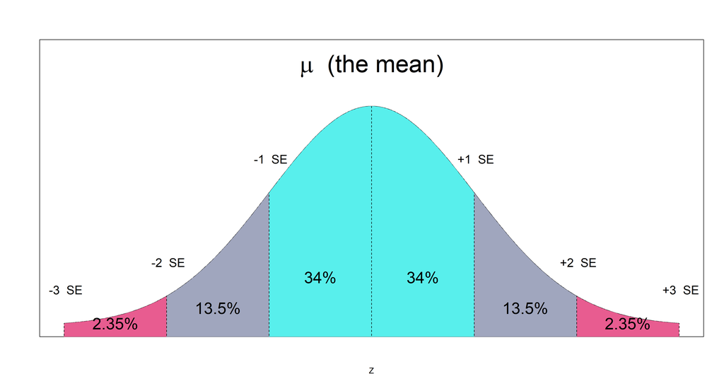

# Confidence

## Confidence Intervals

Confidence intervals (and the related concept of a Margin of Error) are one way to use this knowledge to quantify our uncertainty about an estimate from a sample.

## Confidence Intervals

Confidence Intervals will be expressed in terms of percentages (95% CI, 90% CI etc.)

And a 95% confidence interval is the range that we are 95% certain contains the population parameter.

## Confidence Intervals

Let’s say the NHANES gives us an average estimated adult height of about 169 centimeters (5 ft. 5 in.), a sample variance of about 102 and a sample size of 7424.

## Confidence Intervals

We *don’t* know the population mean, but we do know that the sampling distribution is centered around it, so the error distribution should be centered on 0 and have a standard deviation of $\sqrt{\frac{s^2}{n}} = \sqrt{\frac{102}{7424}} \approx 0.12$

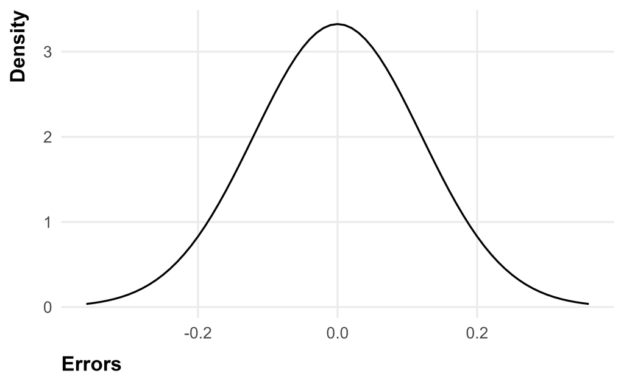

## Confidence Intervals

We also that 95% of the density of a normal distribution will fall within about 1.96 standard deviations of the mean, so this region [-0.235,0.235] gives us the range that contains 95% of the sampling errors. (Half this range is our *margin of error*)

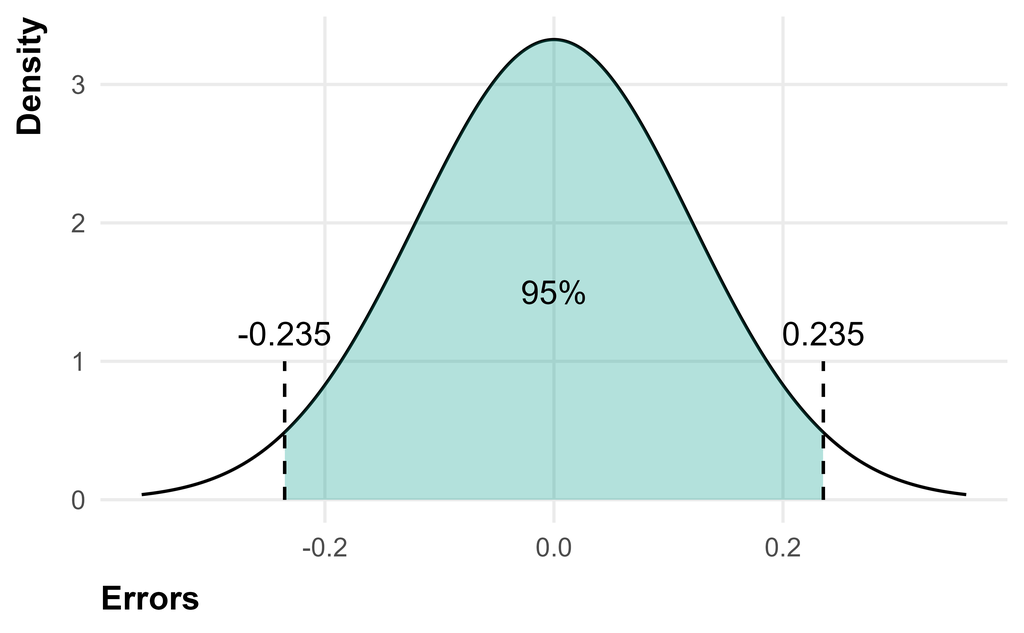

## Confidence Intervals

Adding/Subtracting this range around our point estimate gives us a 95% confidence interval that ranges from 168.765 to 169.235.

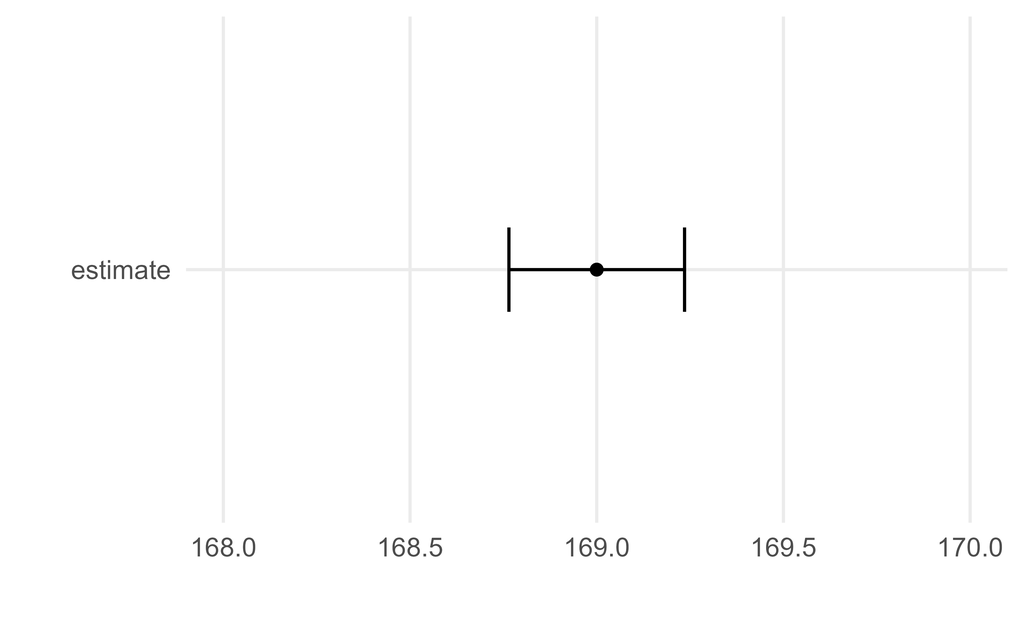

## Confidence Intervals

> We’re 95% confident that the population height is between 168.765 to 169.235.

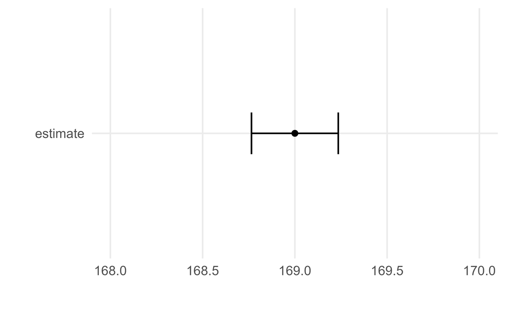

## Confidence Intervals

Important technical note: this *isn’t* the same as saying that there’s a 95% chance that the population height ranges between 168.765 169.235! Confidence intervals are a statement about our own confidence in our sample.

## Confidence Intervals

A 95% CI means “95% of confidence intervals calculated this way would contain the population parameter.”

[figure not shown]

## Confidence Intervals

You can see this yourself using some simulated samples:

```r
set.seed(999)

Mu<-0 # population mean

population<-rnorm(10000, mean=Mu, sd=1) # our simulated population
# a function to calculate a ci from a sample
ci<-function(x, level=.95){
  alpha<-1- (1-level)/2
  mu <- mean(x)
  se<-sqrt(sd(x)/length(x))
  moe<- se * qnorm(alpha)
  return(c(lb = mu - moe, ub = mu + moe))

}
# drawing 10,000 samples and calculating 95% Confidence intervals
sampled_ci<- replicate(10000, ci(sample(population, size=50), level=.95))|>
  t()|>
  data.frame()

# approximately 95% of these confidence intervals should contain Mu
mean(sampled_ci$lb<Mu & sampled_ci$ub>Mu)
```

[output not shown]

## Margin of Error

The margin of error reported on a poll will use similar math.

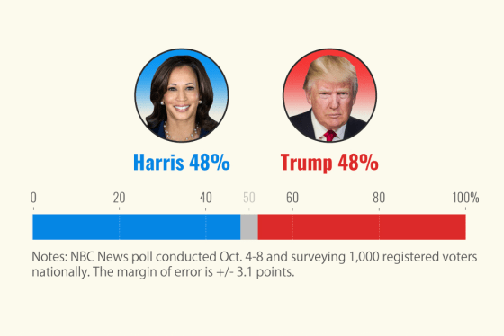

## Margin of Error

Using the simplified formula for the variance of a proportion:
$$s^2 = .48 (1-.48) \approx .25$$

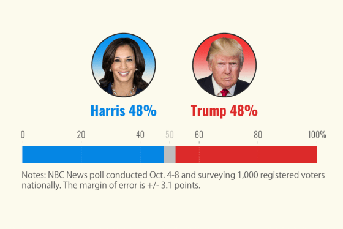

# Caveats

## Surveys and Confidence Intervals

Two additional considerations that are specific to working with survey data:

- Finite Population Corrections
- The effect of clustering, stratification, and weighting.

## Surveys and Confidence Intervals: Finite Population Corrections

The CLT assumes that samples are drawn *with replacement*, but this is rarely how surveys are conducted. The finite population correction accounts for this discrepancy.

### Finite Population Correction

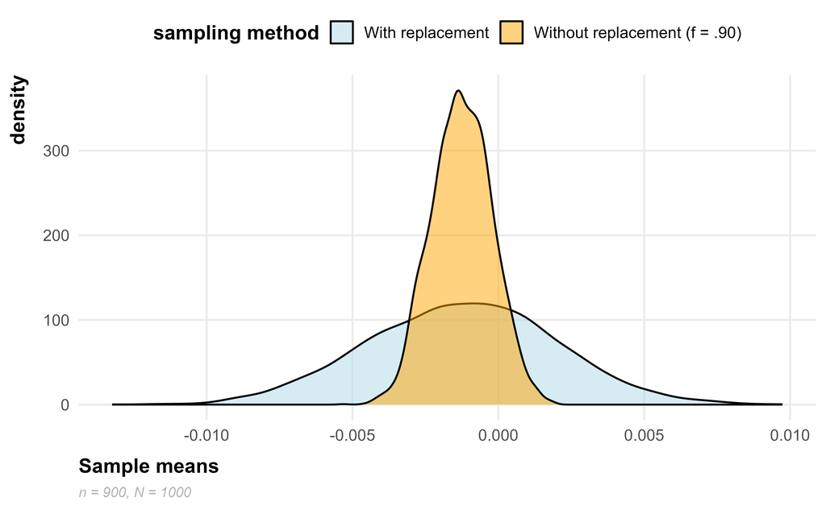

### Finite Population Correction

Variance when sampling with replacement:
$$SE(\bar{y}) =\sqrt{\frac{1}{n} s^2}$$

Variance when sampling without replacement ($f$ is the sampling fraction)

$$SE(\bar{y}) =\sqrt{\frac{1-f}{n} s^2}$$

### Finite Population Correction

- In practice, FPC will have a negligble effect unless the sampling fraction is quite large.
- For instance, our NHANES sample had an $n$ of $7,424$ and we had about $345$ million adults, so $f = 0.00002151884$

$SE(\bar{y}) =\sqrt{\frac{1-0.00002151884}{7424} 102} = 0.1172132$

$SE(\bar{y}) =\sqrt{\frac{1}{7424} 102} = 0.1172144$

### Finite Population Correction

As a rule of thumb, the FPC is generally only applied when the sampling fraction is above .05, and even then it may have a negligible effect.

### Clustering, stratification and weighting

- The Central Limit Theorem is based on the assumption that we’re drawing simple random samples, where each element has an eqaul chance of being included.
- Few surveys use this approach.

### Clustering, stratification and weighting

- Clustering (sampling entire groups instead of individuals) will generally increase variance.
- Stratification (sampling within subgroups) will usually decrease variance.
- Survey weights also tend to inflate variance, but may needed to correct biases.

We’ll discuss these issues in more detail in a later class.

[figure not shown]